# exFINDER identifies differentiation-associated external signals during zebrafish neural crest (NC) development.

Changhan He

02 三月, 2023

This vignette outlines the steps of applying exFINDER to zebrafish single-cell transcriptomics data on: (1) identifying external signals associated to the differentiation from earlyNC cells to skeletal and pigment cells; (2) inferring and analyzing the external signal-target signaling network (exSigNet); (3) visualizing the results.

We analyze a scRNA-seq dataset for the cranial NC cells that contribute to zebrafish’s first pharyngeal arch (PA1) (Tatarakis et al., Cell reports, 2021). In the paper, authors showed cells differentiate from early NC cells to pigment cells and skeletal cells with the presence of transitional cells during this differentiation process occurring at around 18hpf. Here we use exFINDER to find the external signals produced by non-NC cells or the external environment that may drive differentiation.

## Load the required libraries

```r
library(exFINDER)
library(Seurat)
library(ggplot2)
library(patchwork)
library(RColorBrewer)
library(dplyr)
library(pheatmap)
library(ggraph)
```

# Part I: Data input & processing & visualizing

exFINDER requires two user inputs: one is the gene expression data of cells, and the other is either user assigned cell labels.

*For the gene expression data matrix*, genes should be in rows with rownames and cells in columns with colnames. Normalized data is required as input for CellChat analysis.

```r
# load complete dataset with cell labels
# this dataset can be download from: https://figshare.com/s/2a674f8342abdf195fb6
Data1 <- readRDS("/Users/chang/Documents/exFINDER/testdata/Tatarakis2021_Zebrafish_Arch1_aggregate_unfiltered.RDS")
Data1@meta.data$Type <- as.factor(Data1@meta.data$guided_cell_type)

# load NC-cell dataset with cell labels
# this dataset can be download from: https://figshare.com/s/54cc0e83f734995d8d2e
Data2 <- readRDS("/Users/chang/Documents/exFINDER/testdata/Tatarakis2021_Zebrafish_Arch1_new_aggregate_filtered_noNT.RDS")
# NC-cell labels can be download from: https://figshare.com/s/6538f43bf233abd9f288
celltypes <- as.factor( read.csv(file = '/Users/chang/Documents/exFINDER/testdata/Tatarakis2021_Zebrafish_Arch1_new_aggregate_filtered_noNT_celltypes.csv')[,2] )
Data2@meta.data$Type <- celltypes
```

```r
# select non-NC cells according to the paper: Tatarakis D et al. Cell reports, 2021, 37(12): 110140. (Fig. 1C)
Data1 <- subset(x = Data1, subset = (Type == "earlyNC" |
                                       Type == "Endothelium" |
                                       Type == "Epithelium" |
                                       Type == "Heart primordium"|
                                       Type ==  "neural_glial" |
                                       Type == "NT" |
                                       Type == "other" |
                                       Type == "pigment" |
                                       Type == "skeletal" |
                                       Type == "unassigned"))

# merge "other" and "unassigned" to "transition" and fix the unportable labels
library(forcats)
Data1@meta.data$Type <- fct_collapse(Data1@meta.data$Type, "transition"=c("other","unassigned"),
                                     "Heart_primordium"="Heart primordium")
Data1@meta.data$Type <- fct_drop(Data1@meta.data$Type)
Data2@meta.data$Type <- fct_collapse(Data2@meta.data$Type, "transition"=c("other","unassigned"))
```

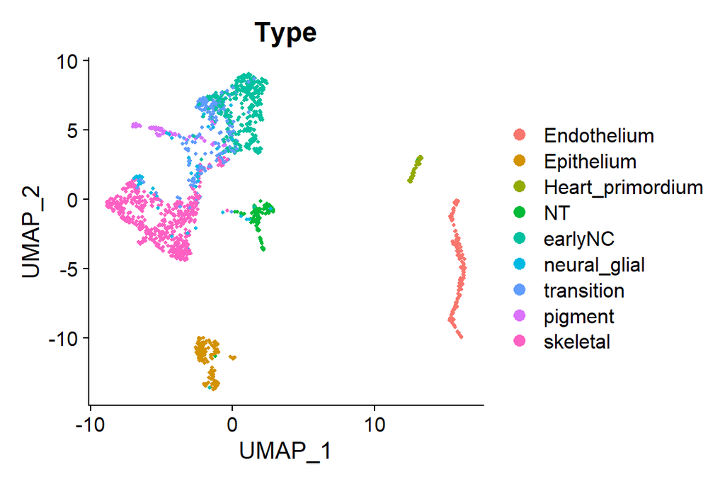

```r
# visualze the complete dataset
DimPlot(object = Data1, group.by = "Type", pt.size = 0.75)
```

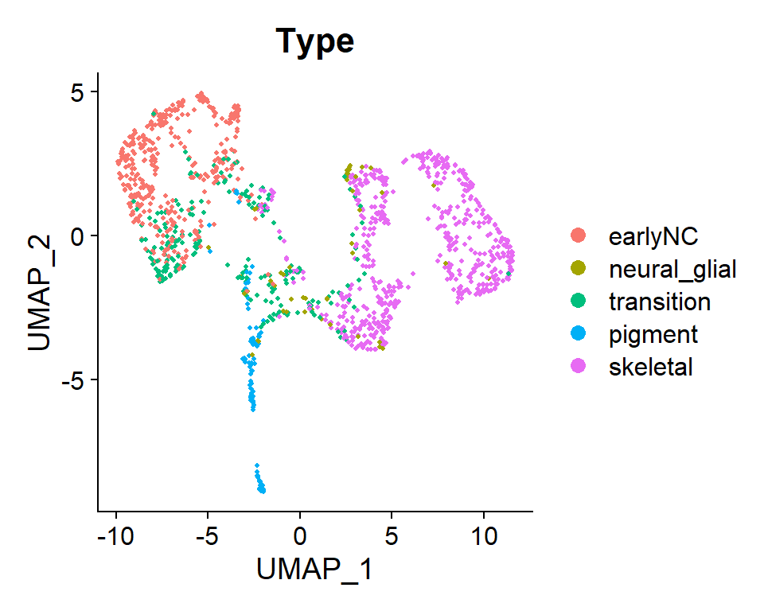

```r
# visualze the NC-cell dataset
DimPlot(object = Data2, group.by = "Type", pt.size = 0.75)
```

All marker genes are analyzed by running the following chunck and saved in folder “../markers/Tatarakis2021_Zebrafish_marker”.

```r
# if needed, users can discover and save marker genes of each cluster by running this chunk (optional)

# Type <- levels(Data1@meta.data$Type)
# n <- length(Type)
# Data1.marker <- c()
#
# for (i in 1:n) {
#   cluster.markers <- FindMarkers(Data1,
#                                  ident.1 = Type[i] ,
#                                  group.by = "Type",
#                                  only.pos = TRUE,
#                                  min.pct = 0.25,
#                                  logfc.threshold = 0.25)
#
#   cluster.markers %>%
#     slice_max(order_by = -p_val)
#   cluster.markers <- cluster.markers[1:100,]
#
#   Data1.marker <- c(Data1.marker, rownames(cluster.markers[1:10, ]))
#
#   write.csv(x = cluster.markers , file = paste("../markers/Tatarakis2021_Zebrafish_marker/Tatarakis2021_Zebrafish_markers_",Type[i],".csv",sep=""))
# }
```

Once all marker genes are saved, we can visualize the top10 markers of each group by running the following chunck.

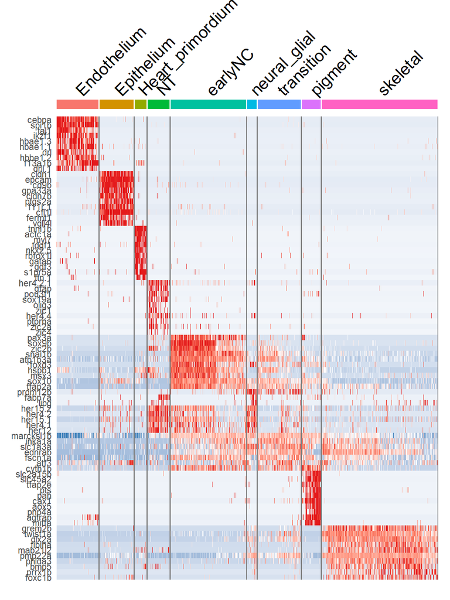

```r
# if all marker genes are saved, we can directly load and visualize
Type <- levels(Data1@meta.data$Type)
n <- length(Type)
Data1@active.ident <- Data1@meta.data$Type
Data1.marker <- c()

for (i in 1:n) {
  cluster.markers <- read.csv(file = paste("../markers/Tatarakis2021_Zebrafish_marker/Tatarakis2021_Zebrafish_markers_",Type[i],".csv",sep=""))

  cluster.markers <- cluster.markers$X[1:10]

  Data1.marker <- c(Data1.marker, cluster.markers)
}

DoHeatmap(Data1, features = Data1.marker) + NoLegend() +
  scale_fill_gradientn(colors = c("#377EB8", "white", "#E41A1C"))
```

# Part II: Load exFINDER database (and optional ligand-receptor database)

*exFINDER database* is available for human, mouse, and zebrafish. *ligand-receptor database* is used for inferring functionally related signaling pathways from the exSigNet, here we use the ligand-receptor database from CellChat.

```r
# load exFINDER database
load("../data/LR_layer1_zebrafish.rda")
load("../data/RTF_layer2_zebrafish.rda")
load("../data/TFT_layer3_zebrafish.rda")

exFINDER.Z <- list()
exFINDER.Z[[1]] <- LR_layer1_zebrafish
exFINDER.Z[[2]] <- RTF_layer2_zebrafish
exFINDER.Z[[3]] <- TFT_layer3_zebrafish
```

Optional: the CellChat ligand-receptor database is used to infer the functionally related signaling pathways.

```r
# load CellChatDB
# CellChatLR.human = load("../data/interaction_input_CellChatDB_human.rda")
# CellChatLR.mouse = load("../data/interaction_input_CellChatDB_mouse.rda")
load("../data/interaction_input_CellChatDB_zebrafish.rda")
```

## Prepare the inputs for exFINDER analysis

```r
# dataset of NC cells
exp.data <- Data2@assays$RNA@data
meta.data <- Data2@meta.data

# the complete dataset contains the data of non-NC cells, which are defined as "external cells"
exp.Exdata <- Data1@assays$RNA@data
meta.Exdata <- Data1@meta.data
```

calculate the percentile values of cell groups for determining the cutoff thresholds for “barely expressed genes” and “highly expressed genes” in later analysis

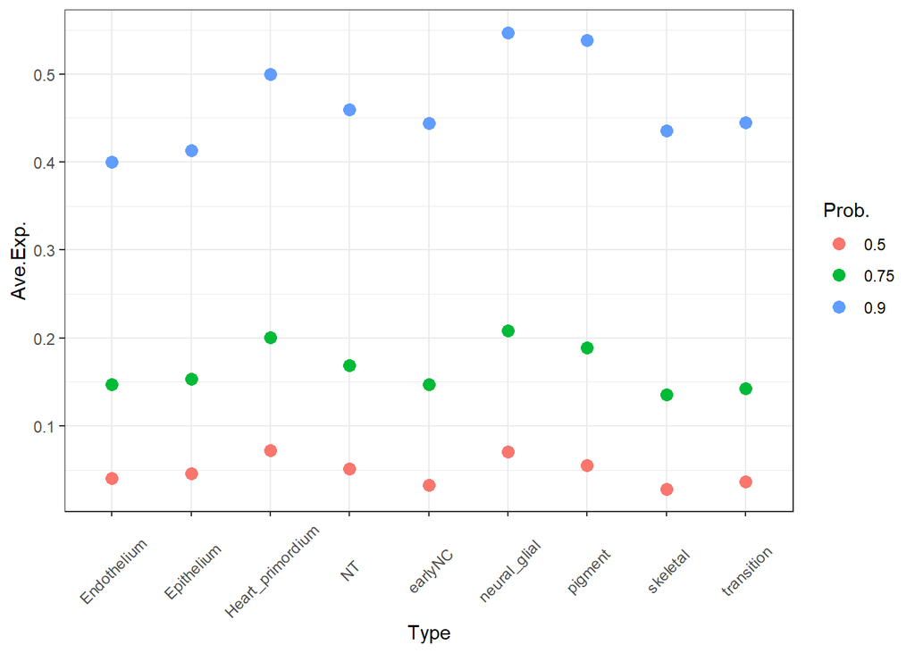

```r
data4 <- get_percentile(Exp.Data = exp.Exdata,
               Meta.Data = meta.Exdata,
               percentile = c(.5, .75, .90))

ggplot(data=data4, aes(x=Type, y=Ave.Exp., color=Prob.)) +
  geom_point(size=3) +
  theme_bw() +
    theme(axis.text.x = element_text(angle = 45, hjust = 0.5, vjust = 0.5))
```

# Part III: Identify external signals that come from NON-NC cells targeting skeletal cells

To identify differentiation-associated external signals, we select the marker genes of skeletal cells (one of the differentiated cell groups) as our target genes. However, the target genes *do not have to be* marker genes.

## Setup target genes and infer ltGRN

```r
marker <- read.csv(file = "../markers/Tatarakis2021_Zebrafish_marker/Tatarakis2021_Zebrafish_markers_skeletal.csv")
target.gene <- marker$X[1:10]
# inter ltGRN
ltGRN <- get_ltGRN(Target = target.gene, DB = exFINDER.Z)
```

## Identify external signals and infer exSigNet

```r
# infer potential external signals from ltGRN
# may be highly expressed in the non-NC cells or external environment
Pex <- get_potentialex(Graph = ltGRN,
                Exp.Data = exp.data,
                Meta.Data = meta.data,
                cutoff = -0.072,
                AG.L = NULL)
head(Pex)
```

```
#> [1] "l1cama" "cntn2"  "ncam1a" "tnfa"   "tnfb"   "anxa1a"
```

Next, we can infer the corresponding receptors, TFs, and target genes high expressed in the assigned cell groups, as well as the signaling network.

```r
# infer exSigNet (R, TF, T are all highly expressed, L comes from the potential external signals)
exSigNet <- get_exSigNet(Graph = ltGRN,
                       Ligands = Pex, # the ligands must be potential external signals
                       Exp.Data = exp.data,
                       Meta.Data = meta.data,
                       par.cutoff = c(0.6, 0.6),
                       # we select the receptors that are highly expressed in the transition and skeletal cells
                       # (around bifurcation point)
                       AG.R = c("skeletal", "transition"),
                       # we select the receptors that are highly expressed in the skeletal cells
                       AG.TF = c('skeletal'))
```

```
#> [1] "No overlap found!"
```

```r
get_NetworkDetail(exSigNet) # show the details of exSigNet
```

```
#> Number of ligands:  51
#> Number of receptors:  9
#> Number of tfs:  25
#> Number of targets:  7
#> Number of L-R pairs:  59
#> Number of R-TF pairs:  76
#> Number of TF-T pairs:  71
```

We can check the expression levels of the inferred ligands (external signals), their expression levels in the NC cells should be very low.

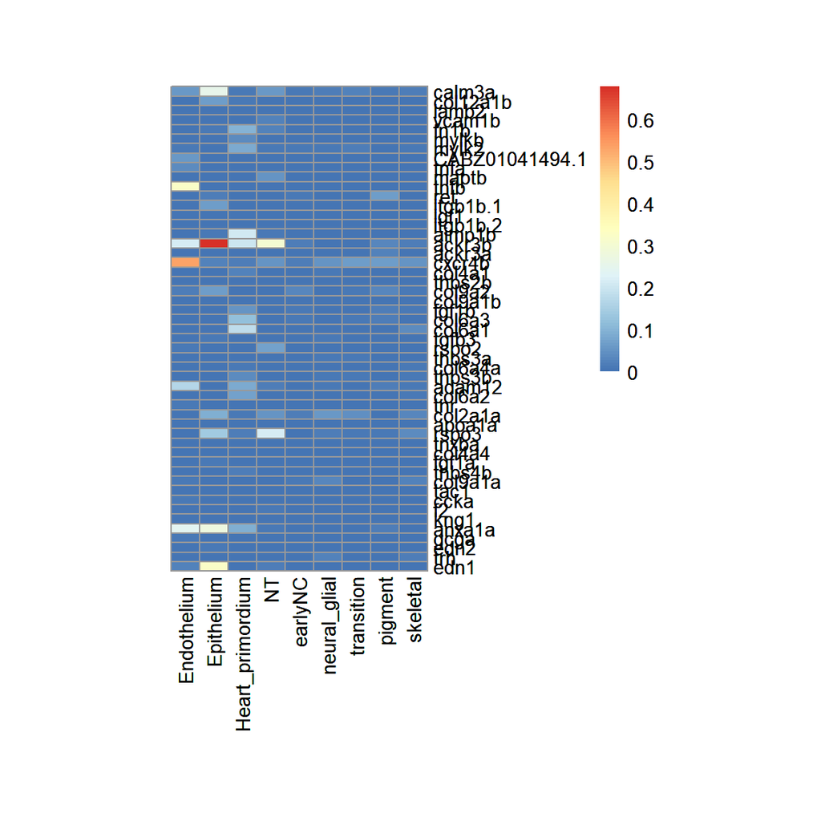

```r
# check the inferred external signals and their expressions via heatmap
exS <- exSigNet$Graph.Node$Gene[exSigNet$Graph.Node$Role == "Ligand"]

get_heatmap(Gene = exS,
            Exp.Data = exp.Exdata,
            Meta.Data = meta.Exdata)
```

Since we also have the single-cell data of non-NC cells, we can regard them as “external cells” and identify the external signals that specifically come from non-NC cells.

```r
# select the external signals that expressed by non-NC cells and infer the corresponding exSigNet
exSigNet <- get_exSigNetExData(Graph = exSigNet,
                                 Exp.ExData = exp.Exdata,
                                 Meta.ExData = meta.Exdata,
                                 cutoff.ExData = 0.6,
                                 # find the external signals that are highly expressed in the non-NC cells
                                 AG.ExData = c('Endothelium','Epithelium','Heart_primordium','NT'))
```

```
#> [1] "No overlap found!"
```

```r
exSigNet
```

```
#> $Graph.Edge
#>       from      to   source           path from.Role  to.Role
#> 1   ackr3b cxcl12b   IUPHAR ackr3b*cxcl12b    Ligand Receptor
#> 2  cxcl12b  ctnnb1 NicheNet cxcl12b*ctnnb1  Receptor       TF
#> 3  cxcl12b   fosab NicheNet  cxcl12b*fosab  Receptor       TF
#> 4  cxcl12b     jun NicheNet    cxcl12b*jun  Receptor       TF
#> 5  cxcl12b   junba NicheNet  cxcl12b*junba  Receptor       TF
#> 6      jun twist1a NicheNet    jun*twist1a        TF   Target
#> 7    fosab twist1a NicheNet  fosab*twist1a        TF   Target
#> 8   ctnnb1 twist1a NicheNet ctnnb1*twist1a        TF   Target
#> 9    fosab  phlda3 NicheNet   fosab*phlda3        TF   Target
#> 10     jun  phlda3 NicheNet     jun*phlda3        TF   Target
#> 11   junba  phlda3 NicheNet   junba*phlda3        TF   Target
#> 12  ctnnb1  phlda3 NicheNet  ctnnb1*phlda3        TF   Target
#> 13     jun  fibina NicheNet     jun*fibina        TF   Target
```

[output cut: 19 more lines]

Then we can calculate expression levels of the genes(nodes), and predict signaling strength(weight).

```r
# calculate the expression levels
exSigNet <- get_NodeValue(Graph = exSigNet,
                          Exp.Data = exp.data,
                          Meta.Data = meta.data,
                          AG.R = c("skeletal", "transition"),
                          AG.TF = c('skeletal'),
                          AG.T = c('skeletal'),
                          Exp.ExData = exp.Exdata,
                          Meta.ExData = meta.Exdata,
                          # the expression of external signals are calculated using the data of non-NC cells
                          AG.ExData = c('Endothelium','Epithelium','Heart_primordium','NT'))

# predict signaling strengths (the default value of Kh is 2)
exSigNet <- get_EdgeWeight(Graph = exSigNet,
               Kh = 2)
```

### Visualize the exSigNet via heatmap plot

```r
# prepare the dataframe for heatmap plot
exS_exp <- get_AveExp(Gene = exSigNet$Graph.Node$Gene,
           Exp.Data = exp.Exdata,
           Meta.Data = meta.Exdata)

exS_exp.HP <- exS_exp
exS_exp.HP <- exS_exp.HP[, -1]
row.names(exS_exp.HP) <- exS_exp$Gene

exS_exp.HP <- data.frame("Endothelium" = exS_exp.HP$Endothelium,
                     "Epithelium" = exS_exp.HP$Epithelium, 'Heart_primordium' = exS_exp.HP$`Heart_primordium`,
                     "NT" = exS_exp.HP$NT,
                     "earlyNC" = exS_exp.HP$earlyNC, "transition" = exS_exp.HP$transition,
                     "neural_glial" = exS_exp.HP$neural_glial,
                     "pigment" = exS_exp.HP$pigment, "skeletal" = exS_exp.HP$skeletal)
row.names(exS_exp.HP) <- exS_exp$Gene

# customize the row labels and col labels
annotation_col = data.frame(
  CellType = c("non-NC cell", "non-NC cell", "non-NC cell", "non-NC cell", "NC cell", "NC cell", "NC cell", "NC cell", "NC cell"))
rownames(annotation_col) = colnames(exS_exp.HP)

annotation_row <- data.frame(Role = exSigNet$Graph.Node$Role)
row.names(annotation_row) <- row.names(exS_exp.HP)
```

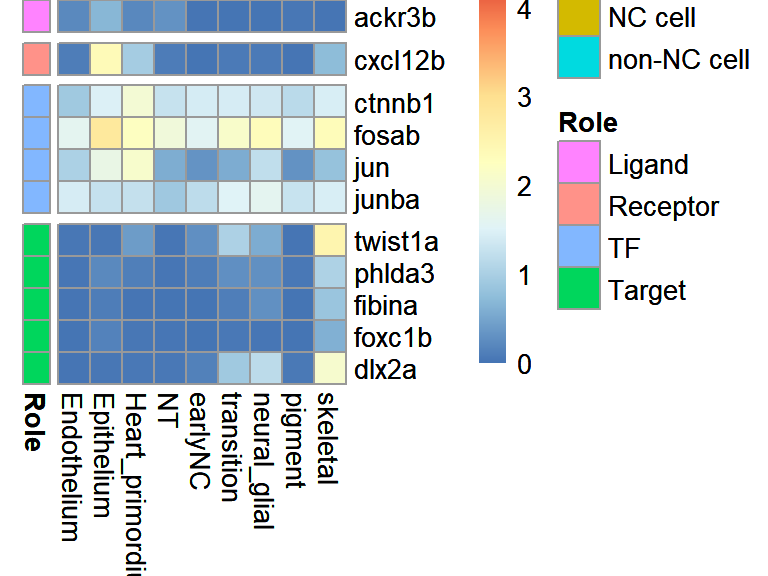

```r
# heatmap plot
bk <- c(seq(0,1.99,by=0.01), seq(2,4.5,by=0.01))

p <- pheatmap(exS_exp.HP,
         cluster_row = FALSE, cluster_cols = FALSE,
         cellwidth = 12, cellheight = 12,
         gaps_row = c(1, 2, 6),
         fontsize_row = 10,
         fontsize_col = 10,
         annotation_row = annotation_row,
         annotation_col = annotation_col,
         color = colorRampPalette(rev(brewer.pal(n = 7, name =
  "RdYlBu")))(length(bk)),
         breaks=bk)

p
```

```r
# ggsave(p, filename="Fig_3d.pdf")
```

### Visualize the exSigNet via hierarchy plot

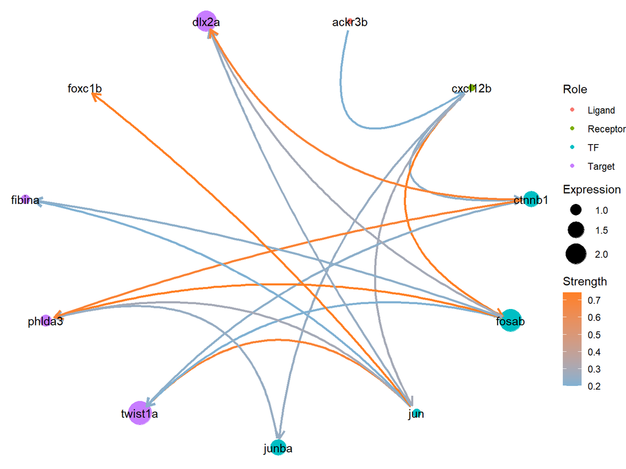

```r
# hierarchy plot
exSigNet_plot <- get_readyforplot(Graph = exSigNet)

p <- ggraph(exSigNet_plot[[1]], layout = 'dendrogram', circular = TRUE) +
  geom_node_point(aes(filter = leaf, x=x, y=y, colour=Role, size=Expression)) +
  theme_void() +
  geom_conn_bundle(data = get_con(from = exSigNet_plot[[2]]$from,
                                  to = exSigNet_plot[[2]]$to,
                                  Strength = exSigNet_plot[[2]]$weight), width = 1.0, aes(colour=Strength),
                   arrow = arrow(length = unit(3, 'mm')), start_cap = circle(3, 'mm'), end_cap = circle(3, 'mm')) +
  scale_edge_color_continuous(low="#80b1d3", high="#FF7F24")+
  geom_node_text(aes(label = node)) +
  scale_size_continuous( range = c(0.1,10) )

p
```

```r
# ggsave(p, filename="Fig_3f.pdf")
```

# Part IV: Identify external signals that come from external environment targeting skeletal cells

Here, *come from external environment* means very low (or zero) expressions in all measured cells (NC and non-NC cells).

## Setup target genes and infer ltGRN

```r
marker <- read.csv(file = "../markers/Tatarakis2021_Zebrafish_marker/Tatarakis2021_Zebrafish_markers_skeletal.csv")
target.gene2 <- marker$X[1:10]

ltGRN.2 <- get_ltGRN(Target = target.gene2, DB = exFINDER.Z)
```

## Identify external signals and infer exSigNet

```r
# infer potential external signals from ltGRN.2: low expression in measured cells
Pex.2 <- get_potentialex(Graph = ltGRN.2,
                Exp.Data = exp.Exdata,
                Meta.Data = meta.Exdata,
                cutoff = -0.072,
                AG.L = NULL)
head(Pex.2)
```

```
#> [1] "l1cama" "cntn2"  "ncam1a" "tnfa"   "kng1"   "penkb"
```

```r
# infer exSigNet.2 (R, TF, T are all high expressed, L comes from the potential external signals)
exSigNet.2 <- get_exSigNet(Graph = ltGRN.2,
                       Ligands = Pex.2,
                       Exp.Data = exp.data,
                       Meta.Data = meta.data,
                       par.cutoff = c(0.6, 0.6),
                       AG.R = c("skeletal", "transition"),
                       AG.TF = c('skeletal'))
```

```
#> [1] "No overlap found!"
```

```r
# exSigNet.2
```

However, some receptors may interact with both external (come from the external environment) and internal signals (expressed by measured cells), which are challenging to evaluate the effect of external signals. We can run the following function to select the receptors that only interact with external signals.

```r
# based on this "exSigNet.2", we identify the receptors that only activated by these external signals
exSigNet.2 <- filterLR_exSigNet(Graph = exSigNet.2,
                  Exp.Data = exp.Exdata,
                  DB = exFINDER.Z)
```

```
#> [1] "No overlap found!"
```

```r
# exSigNet.2
```

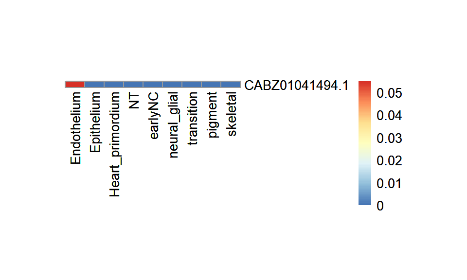

```r
# check the inferred external signals and their expressions via heatmap
exS.2 <- exSigNet.2$Graph.Node$Gene[exSigNet.2$Graph.Node$Role == "Ligand"]

get_heatmap(Gene = exS.2,
            Exp.Data = exp.Exdata,
            Meta.Data = meta.Exdata)
```

Since the ligands come from the external environment, and for the need of quantitative analysis, we set their expression levels equal to 1.

```r
# calculate the expression levels
exSigNet.2 <- get_NodeValue(Graph = exSigNet.2,
                          Exp.Data = exp.Exdata,
                          Meta.Data = meta.Exdata,
                          AG.R = c("skeletal", "transition"),
                          AG.TF = c('skeletal'),
                          AG.T = c('skeletal'),
                          # if there is no expresison data for ligands, exFINDER will set them to 1.
                          Exp.ExData = NULL,
                          Meta.ExData = NULL,
                          AG.ExData = NULL)

# predict signaling strengths
exSigNet.2 <- get_EdgeWeight(Graph = exSigNet.2,
               Kh = 2)
```